# Finding Life Partner

Ruixiong Shi, Danmo Wang, Liu Yi, Rong Wang, Yue Shen Gu

January 27, 2016

# 1 Introduction

In this script we are interested to see that as a graduate master student, assume I am free to choose the place to work, where is the best state to meet my life partner? (we look for a suitable husband/wife not from mentally match but focus on more reality consideration)

Our ultimate goal is end up with a serach engine that can show you the best state based on your preference of life partner.

So let’s start our story here, I am a young lady that will finish my master program on Dec, where should I work?

### 1.1 Libraries we need

```r
library(rCharts)
library(htmltab)
library(rMaps)
library(rCharts)
library(data.table)
library(ggplot2)
library(dplyr)
```

### 1.2 Load data

```r
#select the columns we need
colstokeep<-c("PWGTP", "ST", "SCHL", "AGEP", "SEX", "ESR", "MSP", "WAGP")
pop1<-fread('C:/Users/ygu/Desktop/columbia/csv_pus/ss13pusa.csv', select = colstokeep)
```

```
##
Read 0.0% of 1613672 rows
Read 24.2% of 1613672 rows
Read 47.1% of 1613672 rows
Read 71.9% of 1613672 rows
Read 97.3% of 1613672 rows
Read 1613672 rows and 8 (of 283) columns from 1.416 GB file in 00:00:08
```

```r
pop2<-fread('C:/Users/ygu/Desktop/columbia/csv_pus/ss13pusb.csv',select = colstokeep)
```

```
##
Read 0.0% of 1519123 rows
Read 27.0% of 1519123 rows
Read 53.3% of 1519123 rows
Read 80.3% of 1519123 rows
Read 1519123 rows and 8 (of 283) columns from 1.333 GB file in 00:00:07
```

```r
statename<-read.csv('C:/Users/ygu/Desktop/columbia/cycle1-1/data/statename.csv')
# combine pops
pop<-rbind(pop1,pop2)
```

### 1.3 How many are they?

First of all I want to know and to compare the number of single women and men all over the state (including divorced, widowed and separated people)

The first thing that come into my mind is I need to understand about some information about both single ladies (understand your competitors) and single men.

```r
#excluding married people, and missing values
sindata<-tbl_df(pop)
sindata<-sindata %>%
  na.omit() %>%
  filter(MSP %in% c(3,4,5,6)) %>% #code 1&2 are married
  group_by(SEX)
```

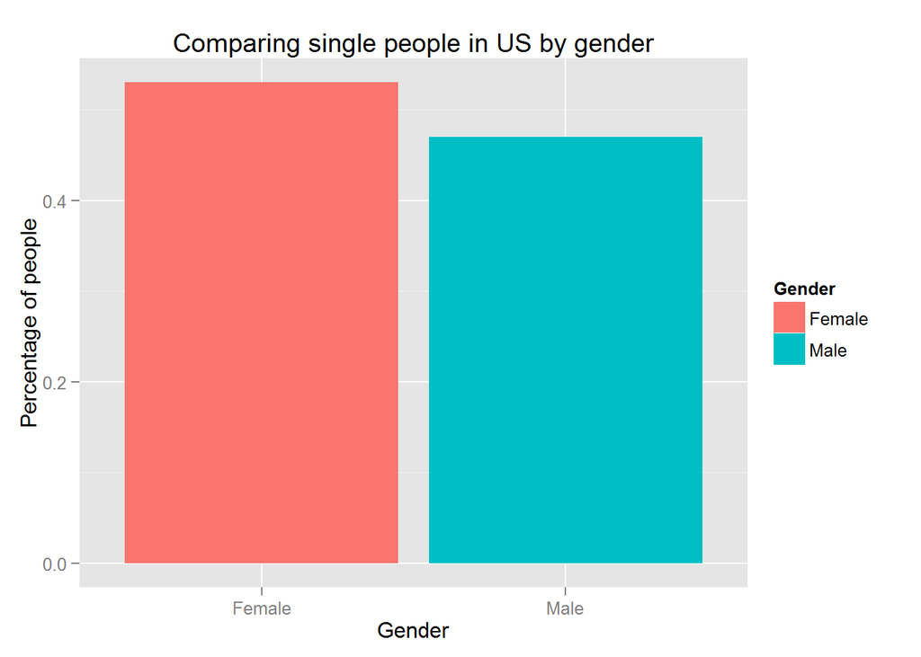

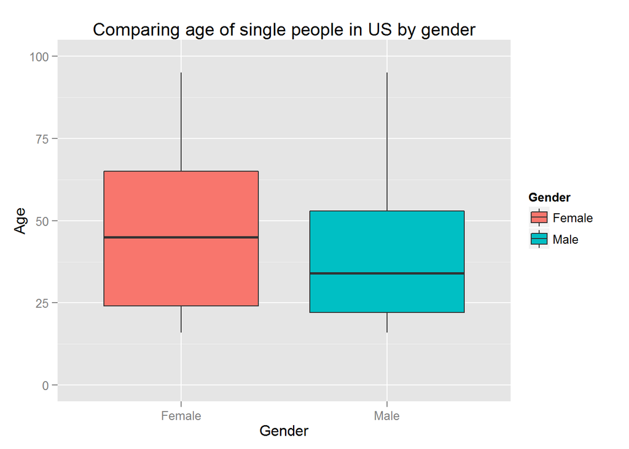

We can see that single female is slightly more than males but half of single female are aobve 45 yeas old.

then we do a quick math:

```r
#Compute the percentage of weighted single people over total population
sum(sindata$PWGTP)/sum(pop$PWGTP)
```

```
## [1] 0.4074829
```

Great! about 40% of population are single even though single ladies are slightly more than single men, I still have a great chance to find a nice husband.

*The next question is, how a nice husband is defined?*.

### 1.4 How about the employment status, income and education level for them?

To my point of view, I do not want to marry a man with a very low income. He should at least have a job and a college degree.

For the next part, I want to know about these information for the single population.

**1.4.1 Employment status**

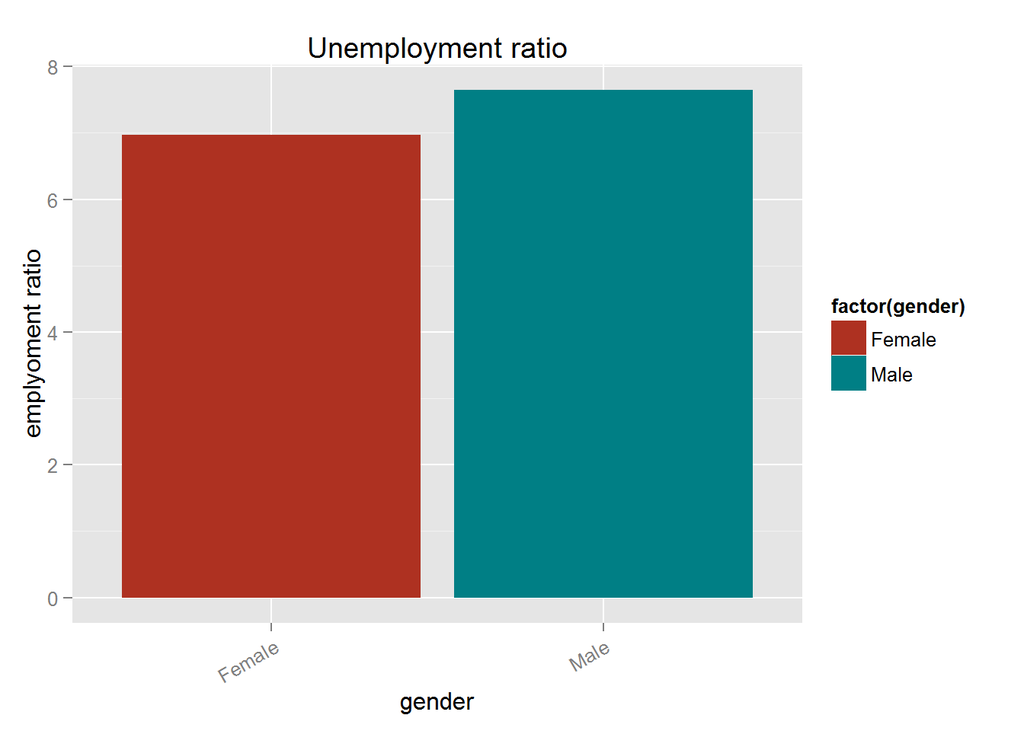

```r
Employment<- pop %>%
na.omit() %>%
  filter(MSP %in% c(3,4,5,6)) %>%
  filter(ESR %in% c(3)) %>% # select person only marked as unemployed
  group_by(SEX) %>% #group by sex
  summarise(count=sum(PWGTP))
```

**1.4.2 Income level**

I break their income into 6 levels and calculate the weighted count

```r
#break the WAGP (lower=0, upper=100000, by=20000)
popudata$WAGP[popudata$WAGP %in% c(0:20000)] <- "0-20k"
popudata$WAGP[popudata$WAGP %in% c(20000:40000)] <- "20-40k"
popudata$WAGP[popudata$WAGP %in% c(40000:60000)] <- "40-60k"
popudata$WAGP[popudata$WAGP %in% c(60000:80000)] <- "60-80k"
popudata$WAGP[popudata$WAGP %in% c(80000:100000)] <- "80-100k"
popudata$WAGP[popudata$WAGP %in% c(100000:1000000)] <- "over 100k"

#sum the weights
popudata<- summarise(popudata,WAGP=WAGP,SEX=SEX,PWGTP=PWGTP)
popudata <- popudata[, lapply(.SD,sum), by=list(SEX,WAGP)]
```

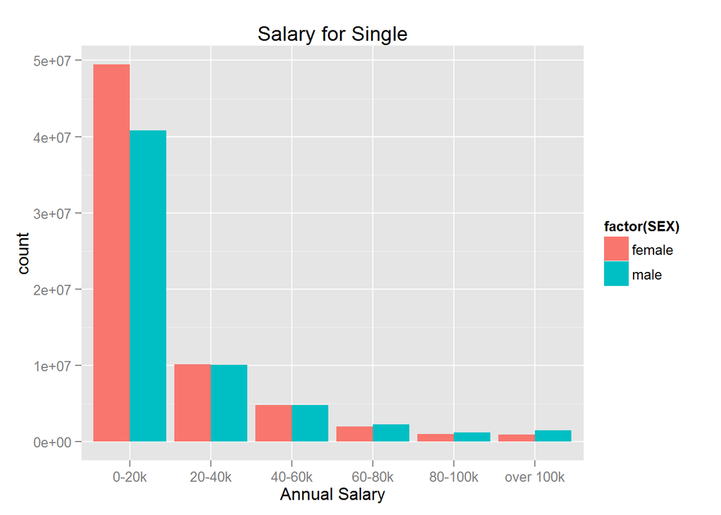

From the above plot, the low paid group(under 20k annual), for both female and male, dominate all other groups.

**1.4.3 Education level**

Change the SCHL codes into different college degrees

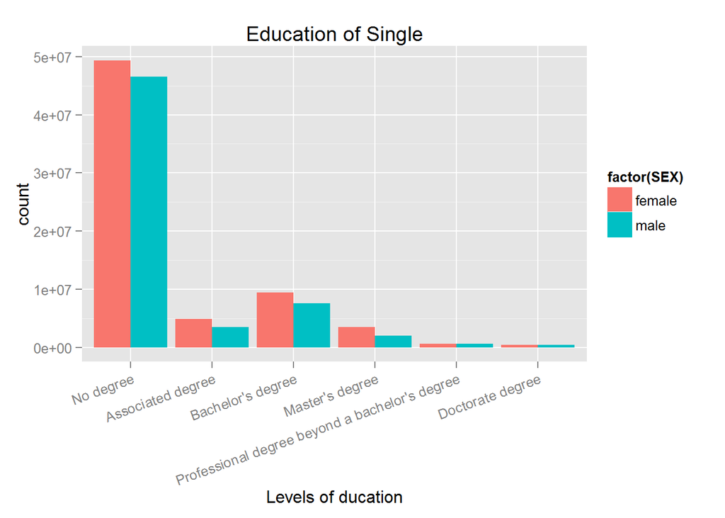

After reading the plots above, I become really nervous about looking for my ideal husband. If I randomly pick a man from US single gentlemen then most of time he is not going to be a perfect husband for me.

Please note that, even you are a young gentlement who is looking for a nice wife, your situation is not optimistic.

# 2 In which states can I find him/her?

As we have seen, finding a good parnter is an intense competition actually, if I want to stand out, I must have some tricks. Here is the trick: I am going to locate one state which has the largest number of my “good” husbands. Also I decide to lower my boyfriend criterion:

*“I want him to have an annual income over 100K, I do not care his age, educaiton or whether he has married before. Basically I just want a sugar daddy.” Women is fickle and you know it*

**2.1 Some library change for this part**

```r
detach(package:dplyr,unload=T)
library(plyr)# these two packages are clashed in some functions
pop4<-pop3[,c('PWGTP','AGEP','CIT','COW','SCHL','SEX','WAGP','WKHP','MSP','single','abbr','RAC1P','FSCHP','name')]

pop4$CIT[pop4$CIT==1]<-'Born in the U.S'
pop4$CIT[pop4$CIT==2]<-'Born in Puerto Rico, Guam, the U.S. Virgin Islands, or the Northern Marianas'
pop4$CIT[pop4$CIT==3]<-'Born abroad of American parent(s)'
pop4$CIT[pop4$CIT==4]<-'U.S. citizen by naturalization'
pop4$CIT[pop4$CIT==5]<-'Not a citizen of the U.S.'
pop4$CIT<-factor(pop4$CIT)

pop4$COW[is.na(pop4$COW)]<-'Less than 16 years old'
pop4$COW[pop4$COW==1]<-'Employee of a private for-profit company'
pop4$COW[pop4$COW==2]<-'Employee of a private not-for-profit'
pop4$COW[pop4$COW==3]<-'Local government employee'
pop4$COW[pop4$COW==4]<-'State government employee'
pop4$COW[pop4$COW==5]<-'Federal government employee'
pop4$COW[pop4$COW==6]<-'Self-employed in own not incorporated'
pop4$COW[pop4$COW==7]<-'Self-employed in own incorporated'
pop4$COW[pop4$COW==8]<-'Working without pay in family business or farm'
pop4$COW[pop4$COW==9]<-'Unemployed and last worked 5 years ago or earlier'
pop4$COW<-factor(pop4$COW)

pop4$SCHL[is.na(pop4$SCHL)]<-'Less than 3 years old'
pop4$SCHL[pop4$SCHL==1]<-'No schooling completed'
pop4$SCHL[pop4$SCHL%in%c(2:3)]<-'Nursery school, preschool, Kindergarten'
pop4$SCHL[pop4$SCHL%in%c(4:15)]<-'Grade 1-12 and no diploma'
pop4$SCHL[pop4$SCHL==16]<-'Regular high school diploma'
pop4$SCHL[pop4$SCHL==17]<-'GED or alternative credential'
pop4$SCHL[pop4$SCHL%in%c(18:19)]<-'Some college, no degree'
pop4$SCHL[pop4$SCHL==20]<-"Associate's degree"
pop4$SCHL[pop4$SCHL==21]<-"Bachelor's degree"
pop4$SCHL[pop4$SCHL==22]<-"Master's degree"
pop4$SCHL[pop4$SCHL==23]<-"Professional degree beyond a bachelor's degree"
pop4$SCHL[pop4$SCHL==24]<-'Doctorate degree'
pop4$SCHL<-factor(pop4$SCHL)

pop4$SEX[pop4$SEX==1]<-'Male'
pop4$SEX[pop4$SEX==2]<-'Female'
pop4$SEX<-factor(pop4$SEX)

pop4$RAC1P[pop4$RAC1P==1]<-'White'
pop4$RAC1P[pop4$RAC1P==2]<-'Black or African American'
pop4$RAC1P[pop4$RAC1P%in%c(3:5)]<-'American Indian or Alaska Native'
pop4$RAC1P[pop4$RAC1P==6]<-'Asian'
pop4$RAC1P[pop4$RAC1P==7]<-'Hawaiian and Other Pacific Islander'
pop4$RAC1P[pop4$RAC1P==8]<-'Other Race'
pop4$RAC1P[pop4$RAC1P==9]<-'2 or More Races'
pop4$RAC1P<-factor(pop4$RAC1P)

pop4$MSP<-factor(pop4$MSP)
pop4$single<-factor(pop4$single)
```

**2.2 Generating plots**

```r
state<-aggregate(pop3$PWGTP, by=list(pop3$abbr,pop3$name), FUN=sum)
names(state)<-c('State','StateName','TotalCountWithWeight')

# Plotting sugar daddy
sugarDaddy<-pop3[pop3$single=='Single'&pop3$SEX==1&!is.na(pop3$WAGP)&pop3$WAGP>=100000,]
sugarDaddy2<-aggregate(sugarDaddy$PWGTP,by=list(sugarDaddy$abbr), FUN=sum)
names(sugarDaddy2)<-c('State','CountWithWeight')
sugarDaddy3<-merge(sugarDaddy2,state,by='State',all.x=T)
sugarDaddy3$Perc<-round(sugarDaddy3$Count/sugarDaddy3$TotalCount*100,1)
sugarDaddy4<-merge(sugarDaddy3,actualPopulation,by='StateName',all.x=T)
sugarDaddy4$ExpectedCount2015<-round(sugarDaddy4$Perc*sugarDaddy4$ActualPop/100,0)

ichoropleth(Perc ~ State,legend=T,pal='YlOrRd',data=sugarDaddy4)
```

### Expected percentage of single males earning more than 100K annually

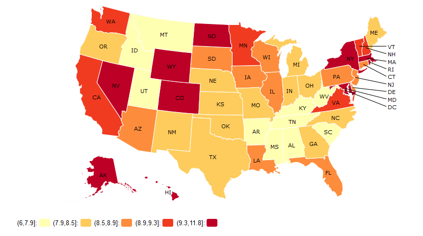

```r
ichoropleth(ExpectedCount2015 ~ State,legend=T,pal='YlOrRd',data=sugarDaddy4)
```